# Gabarito P1

2023-10-02

```r
head(cps4)
```

```
##    wage exper
## 1 18.70    39
## 2 11.50    16
## 3 15.04    13
## 4 25.95    11
## 5 24.03    51
## 6 20.00    30
```

- `wage`: Salário por Hora.
- `exper`: Anos de Experiencia Pós-Educacao.

```r
summary(cps4)
```

```
##       wage            exper
##  Min.   :  1.00   Min.   : 1.0
##  1st Qu.: 11.27   1st Qu.:15.0
##  Median : 16.60   Median :26.0
##  Mean   : 20.14   Mean   :25.9
##  3rd Qu.: 25.00   3rd Qu.:36.0
##  Max.   :173.00   Max.   :70.0
```

1. Faca uma descricao estatística geral das medidas de posição amostrais das varíaveis fornecidas, incluindo a interpretação dos quartis.

Para a variável `wage` pode ser observado que:

- O salário-hora mínimo da amostra é de $1,00 e máximo de $173,00. Como o valor máximo de $173,00 é muito distante do terceiro quartil, há sinais da presença de *outliers* na base de dados.
- O salário médio é de $20,14 e o salário mediano é de $16,60 na amostra. O valor mais elevado da média reforça a hipótese da presença de *outliers* que criam um viés para cima na média (i.e $173,00).
- Para o primeiro e terceiro quartil temos os valores de $11,27 e $25,00, respectivamente, portanto 25% dos indivíduos da amostra têm salário máximo igual ou menor que $11,27. Por fim, o terceiro quartil mostra que 25% dos indivíduos têm salário-hora igual ou maior que $25,00.
- A diferença entre média e mediana e a presença de *outliers* indica que a distribuição dos salários não deve ser uma distribuição normal. Em geral, variáveis como renda e salários apresentam forte assimetria a direita, refletindo os altos níveis de concentração e desigualdade.

Para a variável `exper`:

- O valor minimo é de 1 e máximo de 70 anos de experiência, na amostra.
- Considerando a mediana 26 anos e a média 25 anos, temos que, diferentemente dos salários horas, os anos de experiência não parecem conter valores extremos.
- Para o primeiro e terceiro quartil temos os valores de 15 e 36 anos, respectivamente. Portanto, 25% dos indivíduos na amostra 15 de anos de experiencia ou menos. A partir do terceiro quartil, observa-se que 25% dos indivívuos tem 36 anos de experiência ou mais.
2. Interprete o diagrama de dispersão, indicando se a covariância dos dados $cov(y_i, x_i)$ parece ser positiva ou negativa. Explique, utilizando noções de modelos ou *insights* econômicos, o que poderia justificar a relação observada entre as variáveis.

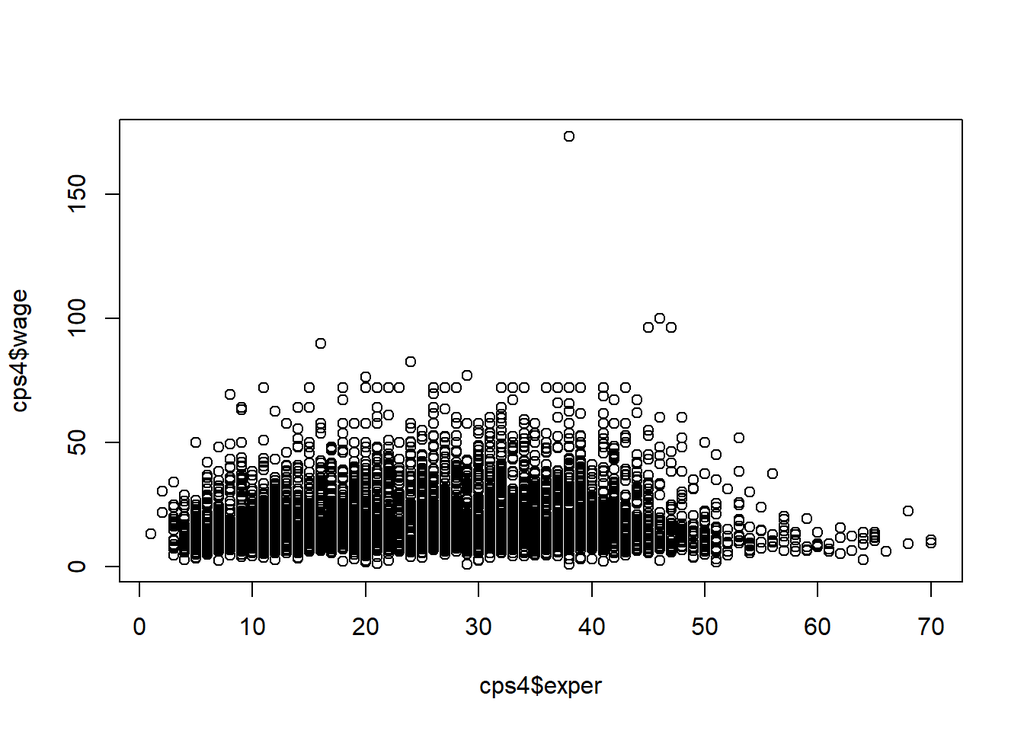

```r
plot(cps4$exper, cps4$wage)
```

O gráfico não é muito claro a respeito do sentido da relação entre as variáveis, isto é, se a covariância entre os salários e anos de experiência é negativa ou positiva. Da perspectiva econômica, porém, espera-se que, tudo o mais constante, os anos de experiência estejam associados a maiores salários-hora. Modelos de cunho neoclássico que explicam a determinação dos salários na economia, concluem, dedutivamente, que os salários reais são determinados pela produtividade marginal do trabalho. Neste sentido, espera-se que a experiência aumente, justamente, a produtividade marginal do trabalho por meio do processo de aprendizagem. **[diferentes respostas poderiam ter sido dadas, com base em diferentes insights ou teorias econônomicas.]**.

3. Escreva a equação do modelo (FRA estocástica) a ser estimada, definindo os termos da mesma (varíaveis dependente e independente, coeficientes de regressão e demais termos presentes)

A FRA estocástica, considerando-se que os coeficientes de regressão ainda serão estimados, é dada por:

$$wage_i = \hat{\beta_1} + \hat{\beta_2}exper_i + \hat{u_i}$$
onde,

$wage_i$ – Variável dependente (Salário por hora, em dólares);

$\hat \beta_1$ – estimativa amostral do intercepto, que representa o valor médio dos salários-hora quando os anos de experiência são zero;

$\hat \beta_2$ – estiamtiva amostral do coeficiente angular, que representa a variação dos salários-hora dada a variação de 1 ano de trabalho;

$exper_i$ – variável independente (Anos de experiência pós-educação);

$\hat u_i$ – termo de erro estocástico, a ser melhor explicado na questão 4).

4. Explique o significado do termo de erro estocástico.

O termo de erro estocástico $u_i$ representa todas as variáveis omitidas no modelo, mas que afetam $Y$, isto é, a variável dependente. Há algumas possíveis razões para que todas essas variáveis não façam parte do modelo proposto:

- *Modelo teórico incompleto*: pode ser que a teoria que explica o comportamento de $Y$, se existe alguma, é incompleta, o termo de erro representaria, portanto, todas essas variáveis excluídas, omitidas ou não identificadas.
- *Indisponibilidade dos dados*: mesmo se soubermos todas as variáveis que explicam a variável $Y$ caso não haja a disponibilidade dos dados não há como estimarmos o modelo com todas elas, então omitimos essas variáveis através do termo de erro.
- *Variáveis essenciais x secundárias*: suponha um modelo que, além da variável $X_i$, também há várias outras variáveis já identificadas, porém que conjuntamente causam um impacto pequeno e consideravelmente irrelevante para a explicação de $Y$. São tratadas, portanto, como uma variável aleatória $u_i$.
- *Aleatoriedade intrínseca do comportamento humano*: mesmo que sejam identificadas todas as variáveis relevante para o modelo, elas nunca irão explicar completamente o comportamento de $Y$, devido à aleatoriedade intrínseca aos valores de $Y$. O termo de erro também engloba essa aleatoriedade.
- *Variáveis proxy pouco adequadas*: na prática os dados podem estar infestados de erros de medição, estes erros são representados também pelo termo de erro estocástico.
- *Princípio da parcimônia*: de acordo com a navalha de Occam, o ideal seria formular o modelo de regressão mais simples possível.
- *Forma funcional errada*: mesmo se as variáveis explanatórias de um fenômeno forem teoricamente corretas e mesmo se encontrarmos dados para essas variáveis, podemos acabar empregando uma forma funcional pouco adequada para estimarmos nosso modelo
5. Escreva a equação da reta do modelo estimado (FRA não estocástica e com os coeficientes de regressão estimados). Interprete os coeficientes de regressão estimados economicamente (intercepto e coeficiente angular)

```r
mod <- lm(wage ~ exper, cps4)
summary(mod)
```

```
##
## Call:
## lm(formula = wage ~ exper, data = cps4)
##
## Residuals:
##     Min      1Q  Median      3Q     Max
## -20.119  -8.771  -3.519   5.242 151.923
##
## Coefficients:
##             Estimate Std. Error t value Pr(>|t|)
## (Intercept) 18.11978    0.40703  44.517  < 2e-16 ***
## exper        0.07782    0.01410   5.518 3.62e-08 ***
## ---
## Signif. codes:  0 '***' 0.001 '**' 0.01 '*' 0.05 '.' 0.1 ' ' 1
##
## Residual standard error: 12.5 on 4836 degrees of freedom
## Multiple R-squared:  0.006256,   Adjusted R-squared:  0.00605
## F-statistic: 30.44 on 1 and 4836 DF,  p-value: 3.616e-08
```

$$\hat{wage_i} = 18.11978 +
0.07782exper_i$$

Interpretação:

- Intercepto: Indica o salário-hora médio que independe dos anos de experiência. Quando consideramos zero (0) anos de experiencia `exper`, tudo o mais constante, o salário hora esperado ou médio será $18,11. Podemos dizer, também, que o intercepto representa o ponto de início da curva de regressão economicamente válida, já que existe uma restrição econômica para o domínio da função especificada, $exper \geq 0$, neste modelo.
- Coeficiente Angular: Dada a variação de uma unidade na variável **independente** `exper`, diga-se o aumento de 1 ano de experiência dos indivíduos, espera-se, em média, uma variação positiva de $0,07 nos salários-hora. Tratando-se de dados amostrais, os valores estimados são estimativas do $E(wage_i | exper_i)$, isto é, dos valores esperados ou médios dos salários, dado os anos de experiência.
6. Bônus: Qual método de estimação foi aplicado para obtenção do modelo? O que esse método busca em relação a Soma dos Quadrados dos Resíduos (SQR). Represente a equação da SQR em função dos coeficientes de regressão.

O método utilizado é o de Minimos Quadrados Ordinários (MQO), que busca encontrar o melhor ajuste para os dados no modelo, a partir da minimização da Soma dos Quadrados dos Resíduos (SQR). Pode-se definir a equação da SQR em função dos coeficientes de regressão. Partimos das equações da FRA (Função de Regressão Amostral) estocástica e da FRA não estocástica, abaixo:

$$Y_i = \hat{\beta}_1 + \hat{\beta}_2 X_i + u_i$$

$$\hat{Y}_i = \hat{\beta}_1 + \hat{\beta}_2 X_i$$

Portanto,

$$Y_i = \hat{Y}_i + u_i$$

E isolando o termo de erro, temos:

$$u^i = Y_i - \hat{Y}_i$$

Substituindo com a expressão para $\hat Y_i$, temos:
$$u^i = Y_i - \hat{\beta}_1 + \hat{\beta}_2 X_i$$

Finalmente, aplicando a soma dos quadrados em ambos os lados da equação, temos:

$$SQR = \sum_{i} u^{2}_i = \sum_{i} (Y_i - \hat{\beta}_1 + \hat{\beta}_2
X_i)^2$$

A equação acima é a expressão da Soma dos Quadrados dos Resíduos (SQR) em função dos coeficientes de regressão a serem estimados. O método de MQO retorna estimativas dos coeficientes de regressão ($\beta_1$ e $\beta_2$) que minimizam a SQR para o conjunto de dados fornecido. Por ser uma função quadrática e de concavidade voltada para cima, a SQR tem um ponto de mínimo. Neste ponto a derivada da SQR, isto é, a inclinação da reta tangente no ponto, é zero.